### Question 01

I get warning messages when I try to assign an object that starts with ‘01’. I know you talked about this in class on Monday but unfortunately I can’t remember if there was a solution to this problem.

- Yes, this was my mistake. I have revised the assignment tab to streamline the naming for you and me. See the update, this should run fine with the new naming convention that I have requested.

### Question 02

The other question regards downloading the ‘datasets’ package to get the mtcars data. Whenever I try to get ‘datasets’ I get a warning message that says “Warning in install.packages: package ‘datasets’ is not available (for R version 3.6.2)” and “package ‘datasets’ is a base package, and should not be updated.” RStudio recommended I download RTools to try to help the problem but it didn’t work. Do you have any advice as to how to fix this?

- I recommend google search engine on warnings and error messages. A search to this effect would show that you have this package on your machine. Type ‘mtcars’ into your console, if you see data, then you have the package installed.

### Question 03

I’m having trouble with my console. I don’t have the other panes, including the Environment pane and the script/console pane I’m not sure about the name. I tried figuring it out but to no avail. Can you help me how to restore this? I attached a photo of how my R console looks like upon opening.

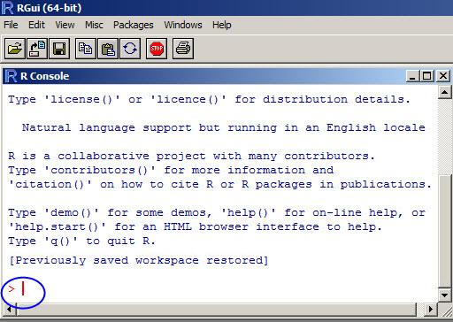

- You are not using Rstudio, you are using R’s built in console. You need to review the course material found here for installing RStudio.

https://rtleaf.github.io/R-shortcourse/01.RStudio.and.R.html

### Question 04

Should I use the assignement operator?

- See this blog post: https://colinfay.me/r-assignment/

### Question 05

I wanted to let you know that I will have to sign out of our zoom session today a little early at 5.

- I leave your learning to you and want to be considerate of your busy research schedule and assistantship duties, attend class as little or much as you like.

### Question 06

“Efficient R programming” helped me immensely with editing the .Rprofile code and understanding what it was that I was editing. I figure passing it along could be helpful for somebody else.

https://csgillespie.github.io/efficientR/r-startup.html

### Question 07

How to create an object, using a loop, that returns c(5, 8, 11, 14) - Zach’s solution

```r
n.vect <- c()
for (i in seq(from = 3, to = 12, by = 3)){
  n.vect[i / 3] <- i + 2
}
```

### Question 08

What is one solution to the “loops excercise” - Zach’s solution

```r
n  <-  4
n.val  <-  0
for (i in 1:n){
  n.val  <-  n.val  +  (i / (i + 1))
}
```

### Question 09

I keep getting an error message “The process cannot access the file because it is being used by another process RStudio IDE”. What is going on?

From “community.rstudio.com”:

When using an RStudio project on OneDrive for Business I pause syncing for a couple of hours (right-click the OneDrive icon in the system tray and select ‘pause syncining >’. It’s a minor irritation to turn it back on again, but it was the workflow I used when I used Google Drive.

Alternatifvely, you could try turning off syncing for the Rproject directory (right-click in your folder in Explorer and click on “Choose OneDrive folders to sync”), but I suspect similar issues might arise as other posts have noted for Dropbox and similar cloud services.

### Question 10

What is the difference between “print” and “return” in functions.

“print” as it names implies print to the console (and return the value printed)

“return” only return the value and ends the function.